# Rodriguez_Perla_T3_Pi.R

## WGCNA

b)A contnuación seguiremos el tutorial que viene en la siguiente dirección. https://horvath.genetics.ucla.edu/html/CoexpressionNetwork/Rpackages/WGCNA/Tutorials/.

## I. Network analysis of liver expression data from female mice: finding modules related to body weight

Los datos son mediciones de la expresión génica de hígados de ratones hembra de un cruce F2 específico. Para obtener una descripción detallada de los datos y las implicaciones biológicas, remitimos al lector a Ghazalpour et al (2006), Integrating Genetics and Network Analysis to Characterize Genes Related to Mouse Weight. Observamos que el conjunto de datos contiene 3600 perfiles de expresión medidos. Estos se filtraron de los más de 20,000 perfiles originales manteniendo solo las sondas más variantes y más conectadas. Además de los datos de expresión, se midieron varios rasgos cuantitativos fisiológicos para los ratones.

Se descarga la carpeta con los datos que viene indicada en el tutorial y se le dice a R que cambie de directorio de trabajo a esta carpeta. Por lo que me voy a la terminal y cambio a mi directorio donde descargue estos datos CON EL SIGUIENTE COMANDO:

**cd FemaleLiver-Data**

### I.1 CARGAR LA LIBRERIA Y LIMPIAR LOS DATOS

```r
library("WGCNA")
# El siguiente comando no debe omitirse
options(stringsAsFactors = FALSE);
```

Ahora leemos nuestros datos

```r
femData <- read.csv("FemaleLiver-Data/LiverFemale3600.csv");
```

Como nuestros datos precargados tienen elementos que no nos sirven, ahora eliminamos los datos auxiliares y transponemos los datos de expresión para su posterior análisis.

```r
datExpr0 = as.data.frame(t(femData[, -c(1:8)]));
names(datExpr0) = femData$substanceBXH;
rownames(datExpr0) = names(femData)[-c(1:8)];
```

### I.2 Revisar los datos para eliminar el exceso de valores perdidos y la identiicación de outliers en muestras de microarreglos.

Primero buscamos genes y muestras con demasiados valores perdidos. El siguiente comando nos dice si tenemos o no valores perdidos, si la respuesta es *TRUE* todos nuestros genes han pasado el análisis

```r
gsg <- goodSamplesGenes(datExpr0, verbose = 3);
```

```
##  Flagging genes and samples with too many missing values...
##   ..step 1
```

```r
gsg$allOK
```

```
## [1] TRUE
```

Si la respuesta es *FALSE*, eliminamoslas muestras de genes que nos causan problemas con el siguiente comando, (sin embargo para nuestros datos la respuesta ha sido *TRUE*, por lo que no será necesario utilizar el código):

```r
if (!gsg$allOK)
{
# Optionally, print the gene and sample names that were removed:
if (sum(!gsg$goodGenes)>0)
printFlush(paste("Removing genes:", paste(names(datExpr0)[!gsg$goodGenes], collapse = ", ")));
if (sum(!gsg$goodSamples)>0)
printFlush(paste("Removing samples:", paste(rownames(datExpr0)[!gsg$goodSamples], collapse = ", ")));
# Remove the offending genes and samples from the data:
datExpr0 = datExpr0[gsg$goodSamples, gsg$goodGenes]
}
```

Ahora con el siguiente comando agrupamos las muestras para ver si hay outliers obvios.

```r
sampleTree <- hclust(dist(datExpr0), method = "average");
# Plot the sample tree: Open a graphic output window of size 12 by 9 inches
# The user should change the dimensions if the window is too large or too small.
sizeGrWindow(12,9)
#pdf(file = "Plots/sampleClustering.pdf", width = 12, height = 9);
par(cex = 0.6);
par(mar = c(0,4,2,0))
```

Visualizamos nuestros datos y observamos un outlier en la muestra F2_221. Este valor puede ser eliminado a mano o podemos usar un enfoque automático. Elejimos un corte de altura que elimine la muestra infractora, por ejemplo 15 (la línea roja en el diagrama), y usamos un corte de rama a esa altura.

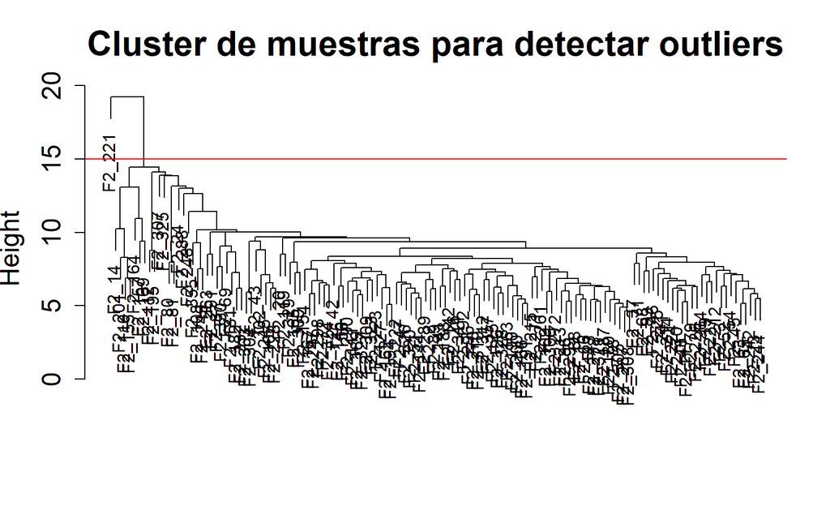

```r
plot(sampleTree, main = "Cluster de muestras para detectar outliers", sub="", xlab="", cex.lab = 1.5,
cex.axis = 1.5, cex.main = 2)
# Ploteamos la linea para mostrar el lugar donde cortaremos

abline(h = 15, col = "red");
```

Ahora definimos los cluster que quedarán debajo de la línea de corte. La variable datExpr ahora contiene los datos de expresión listos para el análisis de red

```r
clust <- cutreeStatic(sampleTree, cutHeight = 15, minSize = 10)
table(clust)
```

```
## clust
##   0   1
##   1 134
```

```r
# El objeto clust 1 contendra las muestras que queremos conservar
keepSamples = (clust==1)
datExpr <-datExpr0[keepSamples, ]
nGenes <- ncol(datExpr)
nSamples <- nrow(datExpr)
```